# Homework 2

Diana Rueda

10/23/2020

# Text Processing: Emails For SPAM/HAM Classification

The approach used in this assignment is simple but posed some challenges before fully establishing it. For each variable created three blocks of code were used. One block containing a function to calculate a single value, one to implement the function in all observations and another to adjust and test the funciton lines of code using emails representative of each scenario. To comfirn the validity of the results I made use of functions such as length, which, sum and is.na as well as indexes to keep track of the location of errors and to randomly test for the specifications. Once I knew which email was causing an error I could read it and see what made it different. Then I would run it by itself to determine which part of the function had a conflicf with it. Finally said function was adjusted to accomodate for emails containing these special characteristics.

The variables I used were: isSpam, isRe, numLinesInBody, bodyCharacterCount, subjectExclamationCount, subjectQuestCount, numAttachments, hasAttachments, priority, percentCapitals, isInReplyTo, hourSent, isPGPsigned, sunjectSpamWords, percentSubjectBlanks, fromNumericEnd, isYelling and percentSubjectCapitals.

My first step was to read the email location names to a variable for later use.

```r
f_names = list.files("~/Documents/SpamAssassinTrain",  recursive = TRUE,  full.names = TRUE) # save name of email files into f_names
length(f_names)
```

```
## [1] 6541
```

## Separating headers, attachments and bodies.

In this section the emails were separated into parts to be used later for the extraction of the variables mentioned before. These functions were the most difficult part to complete since the definition of boundaries varies greatly from email to email. Multiple scenarios had to be taken into account.

### get_headers

The first function is get_headers. This takes an email as input and returns its header by finding the first blank line.

```r
#get_headers function obtains the header of an email
get_headers = function(email) { #takes in the lines of an email
  index = match("", email) #finds the first blank space
  temp_header = email[1:index-1]
  return(temp_header)
}
```

### get_not_header

The next function is get_not_header which takes in an email and returns everything below the header following the same criteria as get_headers.

```r
#function returns the lines of the email that do not belong to the header
get_not_header = function(email) {
  line_index = match("", email)
  line_index = line_index
  not_header = email[line_index:length(email)]
  return(not_header)
}
```

### get_attachments

The following is a funciton to obtain the attachments of an email. For this function a lot of trial and error was involved. The general method is that it finds the line containing the attachment boundary. If no such boundary exists, it returns NA. Once the boundary is found, this line is processed to obtain the opening and closing boundaries. Multiple scenarios are considered and are handled in the apropiate order. Then one of the functions created above is used to work only on the portion of the email that does not contain the header. It uses the not_header and agrep to find the location of boundaries in the email. The function agrep was a better option than grep since it accounts for small boundary inconsistencies. Then I use a for loop and nested if statements to account for the type os attachments I might find. For instance, if the next boundary found (next boundary index which I track with j) is an opening boundary then that attachment ends the line before this index. However if the next boundary is a closing boundary, we include this closing boundary in the the attachment. If no next boundary is found then the end of the attachment is the end of the email. The nested if statement is to account for the special situation in which there is only one attachment boundary in which case we use the end of the email to end the attachment. This was done to solve a conflict between the “next boundary” index tracker j and the length of the vector containing the boundary indeces. In each case the subsetting is appended to a vector containing the email attachments. Finally an additional if-else clause is added to account for the couple of cases were there is a boundary line in the header but no attachments in the email.

```r
#Function to get attachments on vector of complete emails
#third is the charm
get_attachments = function(email){
  #if statement to determine if a boundary = line is found in the email
  if(length(grep("(boundary=|Boundary=|BOUNDARY=)", email, useBytes = TRUE))!=0){ #if a line matching the pattern is found... the email contains a boundary
    boundary_line = grep("(boundary=|Boundary=|BOUNDARY=)", email, useBytes = TRUE, value = TRUE)[1] #obtain first match to the boundary line
    boundary_split = strsplit(boundary_line, "(boundary=|Boundary=|BOUNDARY=)", useBytes = TRUE) #split line at "boundary="
    boundary1 = unlist(boundary_split)[2] #get everything after "boundary="
    boundary2 = gsub("(.*);$", "\\1", boundary1, useBytes = TRUE) #if the boundary contains a semicolon at the end, remove it
    boundary3 = gsub("^\"(.*)\"$", "\\1", boundary2, useBytes = TRUE) #if the boundary is enclosed in quotation marks remove them
    boundary = gsub("\\\\", "\\1", boundary3, useBytes = TRUE) #remove any extra backlash
    #account for the cases containing more arguments in the same line as boundary
    if(gsub("(.*)\";(.*)", "\\1", boundary, useBytes = TRUE)!= boundary){
      boundary = gsub("(.*)\";(.*)", "\\1", boundary, useBytes = TRUE) #remove anything after the semicolon
    }

  }else{
    return(NA)
  }
  open_boundary = paste("--", boundary, sep = "") # create opening boundary by adding -- at the  beginning
  closing_boundary = paste(open_boundary, "--", sep = "") #create closing boundary by adding -- at end
  not_header = get_not_header(email) #get not header of email to find index vecto later
  not_header = unlist(not_header)

  indixes = agrep( boundary , not_header, useBytes = TRUE) #index of all boundaries in not_header
  boundary_index = agrep(open_boundary, not_header, useBytes = TRUE) #index vector of boundaries in not_header
  j=1 #index tracker for use inside loop
  att = vector()
  atts = vector()
  for(i in boundary_index){ #run through all boundaries
    j = j+1 #value of next iteration
    next_b = indixes[j] #value of next boundary index
    if(j <= length(boundary_index)){
      if(not_header[next_b] == open_boundary){ #if next boundary is opening boundary
        start = i
        end = next_b - 1 #exclude the next boundary
        att = not_header[start:end] #subset from opening boundary to line before next opening boundary
        csum = rep(1, length(att))
        att = tapply(att, csum, paste)
        atts = append(atts, att) #append to other attachments in this email

      }else if(not_header[next_b] == closing_boundary){#if next boundary is a closing boundary
        start = i
        end = next_b#include closing boundary
        att = not_header[start:end]#subset from opening boundary to line of next closing boundary
        csum = rep(1, length(att))
        att = tapply(att, csum, paste)
        atts = append(atts, att)#append to other attachments in this email

      }else{ #there is no next boundary
        start = i
        end = length(not_header) #so we use the length of the not_header to find index of last line
        att = not_header[start:end] #subset from opening boundary to end of email
        csum = rep(1, length(att))
        att = tapply(att, csum, paste)
        atts = append(atts, att)#append to other attachments in this email
      }
    }else if(length(indixes)==1){ #in case there is only one opening boundary in the entire email
    start = i
    end = length(not_header)#we use the length of the not_header to find index of last line
    att = not_header[start:end] #subset from opening boundary to end of email
    csum = rep(1, length(att))
    att = tapply(att, csum, paste)
    atts = append(atts, att)#append to other attachments in this email
    }
  }
    if(length(atts)==0){ #if boundary is mentioned in header but not used in the body
    return(NA)
  }else{
    return(atts)
  }
}
```

### get_body

In the following function we use the same criteria as get_attachments but we subset everithing outside the attachments. The workings of this function are the same as in get_attachments. This function returns the lines of body in the email.

```r
#Function to get body
get_body = function(email){
  not_header = get_not_header(email)
  not_header = unlist(not_header)
  if(length(grep("(boundary=|Boundary=|BOUNDARY=)", email, useBytes = TRUE))==0){ #if there are not attachments
    return(not_header) #return the not_header as the body

  }else{
    boundary_line = grep("(boundary=|Boundary=|BOUNDARY=)", email, useBytes = TRUE, value = TRUE)[1]
    boundary_split = strsplit(boundary_line, "(boundary=|Boundary=|BOUNDARY=)", useBytes = TRUE)
    boundary1 = unlist(boundary_split)[2]
    boundary2 = gsub("(.*);$", "\\1", boundary1, useBytes = TRUE)
    boundary3 = gsub("^\"(.*)\"$", "\\1", boundary2, useBytes = TRUE)
    boundary = gsub("\\\\", "\\1", boundary3, useBytes = TRUE)
    if(gsub("(.*)\";(.*)", "\\1", boundary, useBytes = TRUE)!= boundary){
      boundary = gsub("(.*)\";(.*)", "\\1", boundary, useBytes = TRUE)
    }


    open_boundary = paste("--", boundary, sep = "")
    closing_boundary = paste(open_boundary, "--", sep = "")
    indixes = agrep( boundary , not_header, useBytes = TRUE)
    boundary_index = agrep(open_boundary, not_header, useBytes = TRUE)
    j=1
    body = vector()
    bodies = vector()
    first_bstop = indixes[1] -1 #find first boundary
    body = not_header[1:first_bstop] #first section of the body from empty line after header until line before first boundary
    bodies = append(bodies, body) #append to body
    for(i in boundary_index){
      j = j+1
      next_b = indixes[j]
      if(not_header[i]==open_boundary){ #ignore this case since we already counted the first boundary and any opening boundary between other boundaries is part of an attachment and has no body around.

      }else if(not_header[i]==closing_boundary){ #if we find a closing boundary
        if(i == boundary_index[length(boundary_index)]){ #if the closing boundary is the last closing boundary found
          start = i + 1
          end = length(not_header)
          body = not_header[start:end] #subset from the line after this boundary to the end of the email
          bodies = append(bodies, body)#append to body

        }else if(not_header[next_b]==open_boundary){ #if the closing boundary is followed by an opening boundary
          start = i + 1
          end = next_b - 1
          body = not_header[start:end] #subset from the line after the closing boundary until the line before the next opening boundary
          bodies = append(bodies, body)#append to body
        }
      }

    }
  }
  return(bodies)
}
```

After a few attemts at implementing the above functions one email was found that was irregular. It did not have the structure of an email at all, so I decided to remove this file. The following code was used to determine how many of these were there. This was the only file that did not contain a single empty line, so it was easy to identify. Thankfully there was only one occurance.

```r
#play with this to delete non email observations
missing_emails = 0
index_del = vector()
for(i in 1:length(f_names)){
  if (is.na(match("", readLines(f_names[i], warn = FALSE)))){
    missing_emails = missing_emails + 1
    index_del = append(index_del, i)
    }
}

#delete emails in index_del
f_names = f_names[-index_del]
```

## Separate each email by components

In the next blocks I applied the functions get_headers, get_not_headers, get_attachments and get_body to create vectors of only headers, not headers, bodies and attachments. For-loops proved useful in this process because I was able to see which email was causing the issue when one arised. I would then look at this particular instance and I would proceed to modify the corresponding functions accordingly.

```r
#create vector of only headers
header = vector()
headers = vector()
for(i in 1:length(f_names)){
  header = get_headers(readLines(f_names[i], warn = FALSE))
  header = tapply(header, cumsum(header == ""), paste)
  headers = append(headers, header)
}
```

```r
#create vector of not headers
not_header = vector()
not_headers = vector()
for(i in 1:length(f_names)){
  not_header = get_not_header(readLines(f_names[i], warn = FALSE))
  csum = rep(1, length(not_header))
  not_header = tapply(not_header, csum, paste)
  not_headers = append(not_headers, not_header)
}
```

```r
#create vector of attachements
attachment = vector()
attachments = vector()
for(i in 1:length(f_names)){
  attachment = get_attachments(readLines(f_names[i], warn = FALSE))
  csum = rep(1, length(attachment))
  attachment = tapply(attachment, csum, paste)
  attachments = append(attachments, attachment)
}
```

```r
#create vector of bodies
body = vector()
bodies = vector()
for(i in 1:length(f_names)){
  body = get_body(readLines(f_names[i], warn = FALSE))
  csum = rep(1, length(body))
  body = tapply(body, csum, paste)
  bodies = append(bodies, body)
}
```

## Obtaining variables

### isSpam

This function was relatively easy since the emails were already separated into folders based on their spam ham classification. Thus, I used the file path to determine whether the email was spam or ham.

```r
#function to get isSpam vector
n = length(f_names)
is_spam = function(x)
  if (grepl(pattern = "ham", file.path(x))) { #if the file is contain in a folder cwith the word ham in its name, then the email is not a spam
    return(FALSE)
  } else {
    return(TRUE)
  }

isSpam = lapply(f_names, is_spam) #apply to all file names
head(isSpam) #show first results
```

```
## [[1]]
## [1] FALSE
##
## [[2]]
## [1] FALSE
##
## [[3]]
## [1] FALSE
##
## [[4]]
## [1] FALSE
##
## [[5]]
## [1] FALSE
##
## [[6]]
## [1] FALSE
```

```r
length(isSpam)
```

```
## [1] 6540
```

```r
sum(isSpam == TRUE)
```

```
## [1] 1676
```

```r
sum(is.na(isSpam))
```

```
## [1] 0
```

### isRe

isRe: logical if the string Re: appears as the first word in the subject of the message  
This variable was simple enough that a function was not required.

```r
#create isRe vector
isRe = vector()

for(i in 1:length(f_names)){ #loop over all instances

  subject_line = grep("^(Subject: )", readLines(f_names[i], warn = FALSE), value = TRUE, useBytes = TRUE)[1] #first appearance of subject line
  subject_line_content = gsub("(Subject: )", "", subject_line, useBytes = TRUE) #remove "Subjec: "

  if(length(grep("^(Re:)", subject_line_content, useBytes = TRUE))!=0){#if grep matches the line to begin with Re: its length wont be 0 and the value to return will be TRUE
    isRe = append(isRe, TRUE)
  }else{
    isRe = append(isRe, FALSE)
  }

}
```

### numLinesInBody

numLinesInBody integer a count of the number of lines in the body of the email message

```r
#function to count number of lines in body
num_Lines = function(body){
  temp = unlist(body)
  numLines = length(temp) #the lenght of the body
  return(numLines)
}
```

The following code creates a vector with the results of the function above being applied to each element of the vector of bodies previously created.

```r
#pplying the funciton to create the vector of values
numLinesInBody = vector()
for(i in 1:length(f_names)){
  num = num_Lines(bodies[i])
  numLinesInBody = append(numLinesInBody, num)
}
```

### bodyCharacterCount

bodyCharacterCount integer the number of characters in the body of the email message  
Since a function to count characters already exists, I only needed to implement this function along all bodies.

```r
#aplying the function to create the vector of values
bodyCharacterCount = vector()
for(i in 1:length(f_names)){
  num_chars = nchar(bodies[i])
  bodyCharacterCount = append(bodyCharacterCount, num_chars)
}
```

### subjectExclamationCount

subjectExclamationCount integer a count of the number of exclamation marks (!) in the subject of the message

The following function uses grep to extract the subject line, and uses an if statement to account for the email in which this line is missing. Then, it uses the second attribute of gregexpr to count the number of occurances. Since when no matches are found it returns a length of -1 I added another if statement to return a count of 0 when this happens. In cases where there is a positive count, the function uses sum over the attribute length to count the number of exclamation marks in the subject line.

```r
#function to count the number of exclamation marks in the subject line
exclamation_subject = function(email){
  subject_line = grep("^(Subject:)", email, value = TRUE, useBytes = TRUE)[1]
  if(is.na(subject_line)){
    return(NA)
  }
  position = gregexpr("!", subject_line)
  if(sum(attr(position[[1]], "match.length")) < 0){
    count = 0

  }else{
    count = sum(attr(position[[1]], "match.length"))
  }

  return(count)
}
```

```r
#implementation of the fucntion  exclamation_subject to create vector of values
subjectExclamationCount = vector()
for(i in 1:length(f_names)){
  email = readLines(f_names[i], warn = FALSE)
  temp = exclamation_subject(email)
  subjectExclamationCount = append(subjectExclamationCount, temp)

}
```

### subjectQestCount

subjectQuestCount integer a count of the number of question marks (?) in the subject of the message

The function below follows the same organization as the one above (exclamation_subject) but it looks for a question mark as oppose to an exclamation mark. Then I apply it to create a vector of values in the next code block.

```r
#function to find the number of question marks in subject line
question_subject = function(email){
  email = unlist(email)
  subject_line = grep("^(Subject:)", email, value = TRUE, useBytes = TRUE)
  if(length(subject_line)==0){
    return(NA)
  }
  position = gregexpr("(\\?)", subject_line)
  if(sum(attr(position[[1]], "match.length")) < 0){
    count = 0

  }else{
    count = sum(attr(position[[1]], "match.length"))
  }

  return(count)
}
```

```r
#create vector from function through each header
subjectQuestCount = vector()
for(i in 1:length(f_names)){
  email = headers[i]
  temp = question_subject(email)
  subjectQuestCount = append(subjectQuestCount, temp)

}
```

### numAttachments

numAttachments integer the number of attachments in the message.  
This function uses length to obtain the number of attachments, and If the item is NA (missing attachment in vector of attachments) it returns a 0.

```r
#function to count the number of attachments in the input element.
count_att = function(attachment){
  if(attachment == "NA"){
    num = 0
  }else{
    num = length(unlist(attachment)) #unlists the group of attachments and counts each of them
  }
  return(num)

}
```

We apply this function to the vector of attachments through a for-loop

```r
#collect values in vector
numAttachments = vector()
for(i in 1:length(f_names)){
  att = attachments[i]
  temp = count_att(att)
  numAttachments = append(numAttachments, temp)

}
```

### hasAttachments

hasAttachments logical determines if the email contains attachments  
After doing some data visualization I noticed numAttachments does not provide meaningful information about the emails so I decided to use the vector above (numAttachments) to create this logical vector. If the element contains 0 attachments then hasAttachments is FALSE. If the element contains any number of attachments then hasAttachments is TRUE. Then we collect these values in a vector. Perhaps the number of attachments does not matter as much for spam classification as whether or not it contains attachments.

```r
#hasAttachments logical
hasAttachments = vector()
for(i in 1:length(f_names)){
  if(numAttachments[i]==0){
    has = FALSE
  }else{
    has = TRUE
  }
  hasAttachments = append(hasAttachments, has)
}
```

### priority

priority logical whether the message’s header had an X-Priority or X-Smell- Priority that was set to high  
In this case I used grep to identify the lines X-Priority and X-Smell. Then I run this variable through a couple of if statements. The first checks for its length which is equivalent to checking for the existance of those lines in the header. Then with another grep I search for the word high in the previously obtained header lines. If no matches are found the function returns FALSE. Otherwise it returns TRUE.

```r
#function to return logical value of whether the line has high priority
priority_val = function(header){
  header = unlist(header)
  x_line = grep("^(X-Priority:|X-Smell-Priority:)", header, value = TRUE, useBytes = TRUE)
  if(length(x_line) == 0){
    return(FALSE)
  }else{
    prio = grep("(HIGH|High|high)", x_line, value = TRUE, useBytes = TRUE)
    if(length(prio) == 0){
      return(FALSE)
    }else{
      return(TRUE)
    }
  }

}
```

```r
#apply the function to each header and collect the results in a vector
priority = vector()
for(i in 1:length(f_names)){
  header = headers[i]
  val = priority_val(header)
  priority = append(priority, val)

}
```

### percentCapitals

```r
#function to count the number of upper case letters in the body
capital_count = function(body){
  position = gregexpr("[A-Z]", body)
  if(sum(attr(position[[1]], "match.length")) < 0){
    count = 0

  }else{
    count = sum(attr(position[[1]], "match.length"))
  }
  return(count)
}

#function to count the number of lower case letters in the body
lower_count = function(body){
  position = gregexpr("[a-z]", body)
  if(sum(attr(position[[1]], "match.length")) < 0){
    count = 0

  }else{
    count = sum(attr(position[[1]], "match.length"))
  }
  return(count)
}
```

After creating the functions I apply them in a loop through each email’s body. Then in each iteration I calculate the percentage with the total number of letter being lower case plus upper case letters. Then I append each value to a different variable in case I decide to do more analisys with them later even though the only variable required from this section is percentCapitals.

```r
percentCapitals = vector()
numCapitals = vector()
numLower = vector()
for(i in 1:length(f_names)){
  body = bodies[i]
  num_u = capital_count(body) #obtain number of upper case letters
  numCapitals = append(numCapitals, num_u)

  num_l = lower_count(body) #obtain number of lower case letters
  numLower = append(numLower, num_l)

  total_letters = num_u + num_l
  percent = (num_u * 100) / total_letters # calculate the percentage
  percentCapitals = append(percentCapitals, percent) #add percentage to vector

}
```

### isInReplyTo

isInReplyTo logical whether the header of the message has an In-Reply-To field.  
In this function I simply use grep to search for the line starting with In-Reply-To: and if it is empty it returns FALSE. Otherwise it returns TRUE.

```r
#function to find if the header contains the line in reply to
is_reply_line = function(header){
  header = unlist(header)
  replyto_line = grep("^(In-Reply-To:)", header, value = TRUE, useBytes = TRUE)
  if(length(replyto_line) == 0){
    return(FALSE)
  }else{
    return(TRUE)
  }
}
```

```r
#apply the function created above to each header and collect the results in a variable
isInReplyTo = vector()
for(i in 1:length(f_names)){
  temp = is_reply_line(headers[i])
  isInReplyTo = append(isInReplyTo, temp)

}
```

### hourSent

hourSent integer the hour in the day the mail was sent (0-23)  
The approach taken in this function is as follows. First it finds the header line that starts with “Date:” and splits that by the space character. Then it loops over the lenght of the new string and obtains the value of the string that matches the pattern of time. If the time comes in format ##:## we can assume it was sent at hour zero since the time does not show leading zeros. However if time is found in format ##:##:##, we split by : and subset the first element of the result. Finally we convert this to an integer.

```r
#function to get hour at which the email was sent given a header
hour = function(header){
  header = unlist(header)
  date_line = grep("^Date:", header, value = TRUE, useBytes = TRUE) #obtain line starting at Date:
  date_line_split = strsplit(date_line, " ") #split at spaces
  date_line_split = unlist(date_line_split)
  times = vector()
  for(i in 1:length(date_line_split)){ #loop over the new strings
    temp = grep("([0-9]+:{1}[0-9]+:{1}[0-9]+|[0-9]+:{1}[0-9]+)", date_line_split[i], value = TRUE, useBytes = TRUE)# get the string that matches either ##(atleast one):(exactly one)##(at least one):(exactly one)##(at least one) or ##(atleast one):(exactly one)##(at least one)
    if(length(temp) == 0){ #if nothing found in this iteration move on to the next
    }else{
      times = temp #else save the value for later
    }
  }
  if(length(grep("[0-9]+:{1}[0-9]+:{1}[0-9]+", times, value = TRUE, useBytes = TRUE))==0){ #for the case that the time does not match the three space format hour is zero due to missing leading zeros
    hour = 0

  }else{
    times_divided = strsplit(times, ":") #otherwise we separate by the :
    times_divided = unlist(times_divided)
    hour = times_divided[1] #and subset the first element
    hour = as.integer(hour) #to convert to an integer
  }
  return(hour)
}
```

```r
#create vector of hours from headers
hourSent = vector()
for(i in 1:length(f_names)){
  temp = hour(headers[i])
  hourSent = append(hourSent, temp)

}
```

### isPGPsigned

isPGPsigned logical indicates whether the mail was digitally signed (e.g. using PGP or GPG)  
This is a simple function that searches for the letters PGP or GPG in the entire email

```r
#function to determine whether it is pgp signed or not
signed = function(email){
  has_line = grep("PGP|GPG", email, value = TRUE, useBytes = TRUE)
  if(length(has_line)==0){
    return(FALSE)
  }else{
    return(TRUE)
  }

}
```

```r
#assigned function results to logical vector
isPGPsigned = vector()
for(i in 1:length(f_names)){
  not_header = unlist(not_headers[i])
  temp = signed(not_header)
  isPGPsigned = append(isPGPsigned, temp)

}
```

### subjectSpamWords

subjectSpamWords logical whether the subject contains one of the following phrases: viagra, pounds, free, weight, guarantee, millions, dollars, credit, risk, pre- scription, generic, drug, money back, credit card  
In this case grep was used to search for the specific words in the subject line which was obtain with another grep call. The argument ignore.case was set to TRUE to be able to find any matches of those words. The only words it will not match are the ones containing punctuaton marks in the middle. Using agrep was an option but it was possible it would match other words that are only similar.

```r
#function to search for specific words
has_words = function(email){
  email = unlist(email)
  subject_line = grep("^(Subject:)", email, value = TRUE, useBytes = TRUE)[1]
  has_word = grep("viagra|pounds|free|weight|guarantee|millions|dollars|credit|risk|prescription|generic|drug|money back|credit card", subject_line, ignore.case = TRUE,  useBytes = TRUE)
  if(length(has_word) != 0){
  return(TRUE)
  }else{
    return(FALSE)
  }

}
```

```r
#apply function to create vector of logical values
subjectSpamWords = vector()
for(i in 1:length(f_names)){
  temp = has_words(readLines(f_names[i], warn = FALSE))
  subjectSpamWords = append(subjectSpamWords, temp)

}
```

### percentSubjectBlanks

percentSubjectBlanks numeric the percentage of blanks in the subject  
In this function gregexpr was used again for its attribute match.length. It makes using sum more convinient to count the number of apppearances of the desired characters. In addition if statements were used to account for the situation where no matches are found and the attribute gives -1.

```r
#function to count the number of blanks in the subject line
count_blanks = function(email){
  email = unlist(email)
  subject_line = grep("^(Subject: )", email, value = TRUE, useBytes = TRUE)[1]  #obtain first line that starts with Subject:
  position = gregexpr(" ", subject_line) #keep track of the appearances of each blank
  if(is.na(subject_line)){ #if no subject line found at all return NA
    return(NA)
  }else{
    if(sum(attr(position[[1]], "match.length")) < 0){ # if no matches then count = 0
      count = 0

    }else{
      count = sum(attr(position[[1]], "match.length")) #otherwise count equals the sum of the length of each appearance
    }
  }
  return(count)
}

#function to count the number of characters in the line subject which works in the same manner as the one above but it count every character
count_char = function(email){
  email = unlist(email)
  subject_line = grep("^(Subject: )", email, value = TRUE, useBytes = TRUE)[1]
  line_split = strsplit(subject_line, "(Subject: )", useBytes = TRUE)
  position = gregexpr(".", line_split)
  if(is.na(subject_line)){
    return(NA)
  }else{
    if(sum(attr(position[[1]], "match.length")) < 0){
      count = 0

    }else{
      count = sum(attr(position[[1]], "match.length"))
    }
  }
  return(count)
}
```

After creating the functions I apply them in a loop through each email. Then in each iteration I calculate the percentage with the total number of characters and the number of spaces. Then I append each value to a different variable in case I decide to do more analisys with them later even though the only variable required from this section is percentSubjectBlanks.

```r
#calculate the percentage of blanks
percentSubjectBlanks = vector()
numBlanks = vector()
numChar = vector()
for(i in 1:length(f_names)){
  email = readLines(f_names[i], warn = FALSE)
  temp_blanks = count_blanks(email)
  numBlanks = append(numBlanks, temp_blanks)

  temp_char = count_char(email)
  numChar = append(numChar, temp_char)

  percent = (temp_blanks * 100) / temp_char
  percentSubjectBlanks = append(percentSubjectBlanks, percent)

}
```

###fromNumericEnd fromNumericEnd logical whether the user login in the From: field ends in numbers This function obtains the line From: first from the headers. Then it splits the line at @ and subsets the first element. Next it uses grep to check if that first element ends in numbers which would indicate that the user id ends in numbers.

```r
#function to see if the user login ends in numbers
endsin_numbers = function(header){
  header = unlist(header)
  from_line = grep("^(From: )", header, value = TRUE, useBytes = TRUE)[1] #obtain from: line from header
  split_at = unlist(strsplit(from_line, "@", useBytes = TRUE))[1] #split string by @ and subset to obtain the half that contains the user id
  ending_num = grep("[0-9]+$", split_at, value = TRUE, useBytes = TRUE) #match if it ends in at least one number
  if(length(ending_num)==0){ #if the match does not occur then returns FALSE
    return(FALSE)
  }else{
    return(TRUE) #otherwise it returns TRUE
  }

}
```

```r
#apply function to each header in the vector headers and save results in another vector
fromNumericEnd = vector()
for(i in 1:length(f_names)){
  temp = endsin_numbers(headers[i])
  fromNumericEnd = append(fromNumericEnd, temp)

}
```

### percentSubjectCapitals

percentSubjectCapitals numeric tracks the percentage of capital letters in the subject Instead of checking if all letters in the subject line were upper case I desided to look for percentages and then use a treshhold to determine if it is yelling.  
To find the percentage I created two functions to count the number of upper case letters and lowercase letters. I used the same logic as with previous counting functions only that this time I applied it to the subject line and only count letters.

```r
#function to count number of upper case letters in subject line
num_subj_capitals = function(header){
  header = unlist(header)
  subject_line = grep("^(Subject:)", header, value = TRUE, useBytes = TRUE)[1] #obtain subject line
  line_split = strsplit(subject_line, "(Subject: )", useBytes = TRUE)#remove "Subject: " to start the count
  position = gregexpr("[A-Z]", line_split) #locate all the upper case letters
  if(is.na(subject_line)){ #if no subject line return NA
    return(NA)
  }else{
    if(sum(attr(position[[1]], "match.length")) < 0){ #if no upper case letters count = 0
      count = 0

    }else{
      count = sum(attr(position[[1]], "match.length")) #otherwise the count is the sum of the lenght of each appearance
    }
  }
  return(count)
}

#function to count number of lower case letters in subject line
num_subj_lower = function(header){
  header = unlist(header)
  subject_line = grep("^(Subject:)", header, value = TRUE, useBytes = TRUE)[1] #obtain subject line
  line_split = strsplit(subject_line, "(Subject: )", useBytes = TRUE)#remove "Subject: " to start the count
  position = gregexpr("[a-z]", line_split)#locate all the lower case letters
  if(is.na(subject_line)){#if no subject line return NA
    return(NA)
  }else{
    if(sum(attr(position[[1]], "match.length")) < 0){#if no lower case letters count = 0
      count = 0

    }else{
      count = sum(attr(position[[1]], "match.length"))#otherwise the count is the sum of the lenght of each appearance
    }
  }
  return(count)
}
```

A for-loop was used to compute each percentage. In each iteration the functions obtain the number of lower and upper case letters, and the percentage is calculated as well. This number is then appended to a vector.

```r
percentSubjectCapitals = vector()
num_capitals_v = vector()
num_lowers_v = vector()
for(i in 1:length(f_names)){
  num_capitals = num_subj_capitals(headers[i])
  num_capitals_v = append(num_capitals_v, num_capitals)

  num_lower = num_subj_lower(headers[i])
  num_lowers_v = append(num_lowers_v, num_lower)

  total_let = num_lower + num_capitals

  percent_capitals = (num_capitals * 100) / total_let
  percentSubjectCapitals = append(percentSubjectCapitals, percent_capitals)

}
```

### isYelling

isYelling logical whether the subject of the mail is in capital letters from percettage  
The function bellow uses a threshhold of 50% to classify a subject line as yelling or not.

```r
#function uses 50% threshhold to return TRUE or FALSE
yells = function(percentage){
  if(is.na(percentage)){
    return(NA)
  }else if(percentage > 50){
    return(TRUE)
  }else{
    return(FALSE)
  }
}
```

Once the vector of percentages is completed we run it through the function above to obtain a logical vector that determines if the subject line is yelling. The results are saved in a vector.

```r
isYelling = vector()
for(i in 1:length(f_names)){
  temp = yells(percentSubjectCapitals[i])
  isYelling = append(isYelling, temp)
}
```

## Building the dataframe

```r
email_data = data.frame("isSpam" = unlist(isSpam), "isRe" = unlist(isRe), "numLinesInBody" = unlist(numLinesInBody), "bodyCharacterCount" = unlist(bodyCharacterCount), "subjectExclamationCount" = unlist(subjectExclamationCount), "subjectQestCount" = unlist(subjectQuestCount),  "numAttachments" = unlist(numAttachments), "hasAttachments" = unlist(hasAttachments), "priority" = unlist(priority), "percentCapitals" = unlist(percentCapitals), "isInReplyTo" = unlist(isInReplyTo), "hourSent" = unlist(hourSent), "isPGPsigned" = unlist(isPGPsigned), "subjectSpamWords" = unlist(subjectSpamWords), "percentSubjectBlanks" = unlist(percentSubjectBlanks), "fromNumericEnd" = unlist(fromNumericEnd), "isYelling" = unlist(isYelling), "percentSubjectCapitals" = unlist(percentSubjectCapitals))
```

```r
head(email_data)
```

```
##   isSpam isRe numLinesInBody bodyCharacterCount subjectExclamationCount
## 1  FALSE TRUE            183               7461                       0
## 2  FALSE TRUE              9                188                       0
## 3  FALSE TRUE              9                188                       0
## 4  FALSE TRUE              9                188                       0
## 5  FALSE TRUE              9                188                       0
## 6  FALSE TRUE              9                188                       0
##   subjectQestCount numAttachments hasAttachments priority percentCapitals
## 1                0              0          FALSE    FALSE        3.646913
## 2                0              2           TRUE    FALSE        2.222222
## 3                0              2           TRUE    FALSE        2.222222
## 4                0              2           TRUE    FALSE        2.222222
## 5                0              2           TRUE    FALSE        2.222222
## 6                0              2           TRUE    FALSE        2.222222
##   isInReplyTo hourSent isPGPsigned subjectSpamWords percentSubjectBlanks
## 1        TRUE       19       FALSE            FALSE             12.12121
## 2        TRUE       10        TRUE            FALSE             12.12121
## 3        TRUE       10        TRUE            FALSE             12.12121
## 4        TRUE       10        TRUE            FALSE             12.12121
## 5        TRUE       11        TRUE            FALSE             12.12121
## 6        TRUE       10        TRUE            FALSE             12.12121
##   fromNumericEnd isYelling percentSubjectCapitals
## 1          FALSE     FALSE               19.04762
## 2          FALSE     FALSE               19.04762
## 3          FALSE     FALSE               19.04762
## 4          FALSE     FALSE               19.04762
## 5          FALSE     FALSE               19.04762
## 6          FALSE     FALSE               19.04762
```

## Data exploration through visualization

```r
library(ggplot2)
```

After considering multiple relationships the following are the plots that show some significant or expected results.

### isSpam vs percentSubjectCapitals

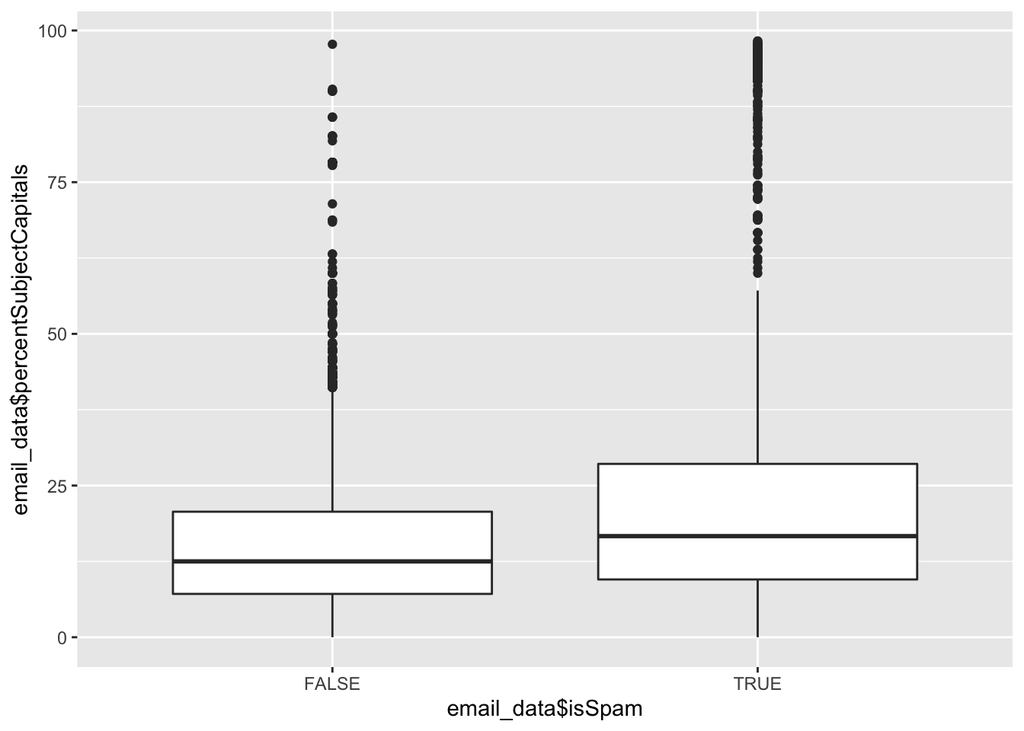

```r
ggplot(email_data, aes(y = email_data$percentSubjectCapitals)) + geom_boxplot(aes(x = email_data$isSpam))
```

This plot compares the percentage of capital letters in the subject line with the spam classification of the email. We can observe that despite the outliers in average spam emails contain more capital letters in their subject lines than non spam emails.

### isSpam vs percent Capitals

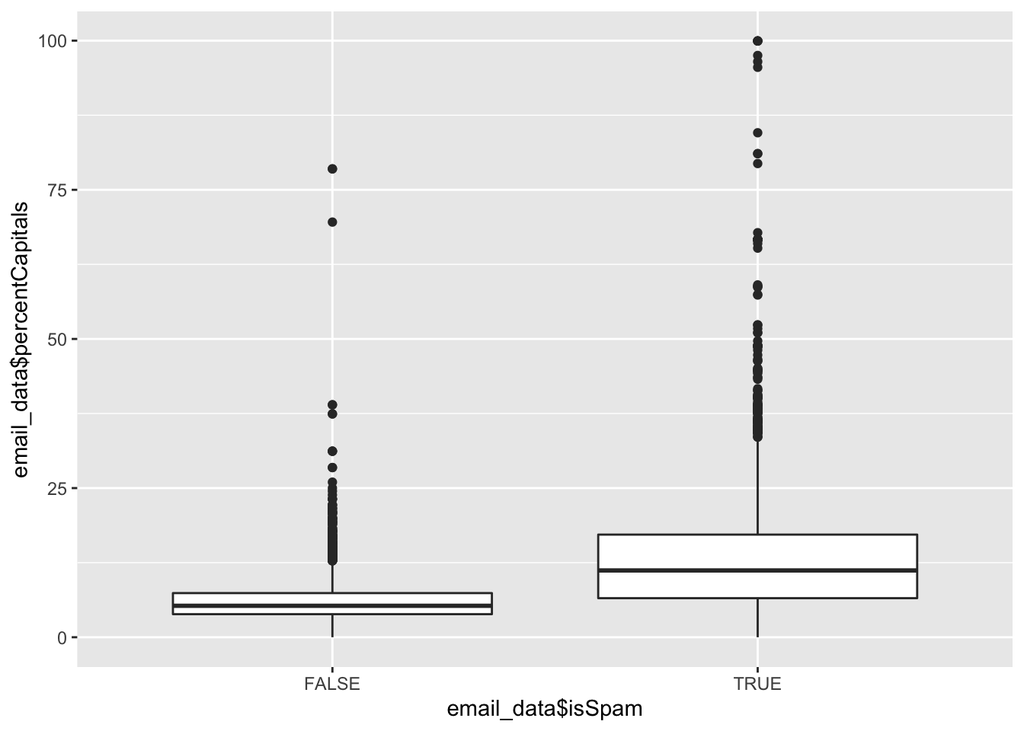

```r
ggplot(email_data, aes(y = email_data$percentCapitals)) + geom_boxplot(aes(x = email_data$isSpam))
```

This plot compares the percentage of capital letters in the body with the spam classification of the email. We can observe that despite the outliers in average spam emails contain more capital letters in their body than non spam emails.

### isSpam vs bodyCharacterCount

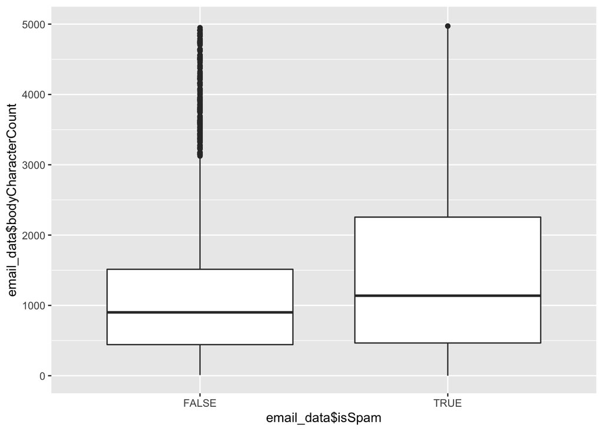

```r
ggplot(email_data, aes(y = email_data$bodyCharacterCount)) + geom_boxplot(aes(x = email_data$isSpam)) +ylim(0,5000)
```

This plot compares the body character count with the spam classification of the email. We can observe that despite the outliers in average spam emails contain more characters than non spam emails.

### isSpam vs numLinesBody

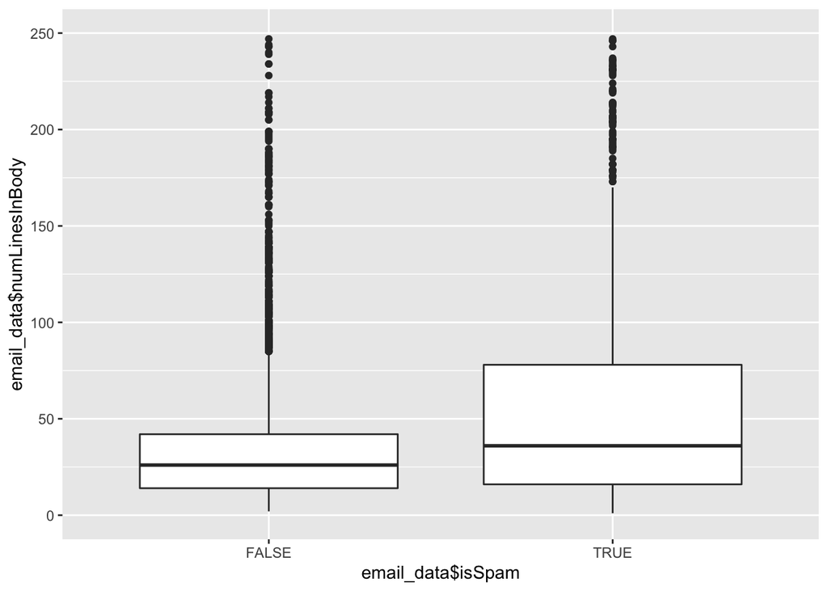

```r
ggplot(email_data, aes(y = email_data$numLinesInBody)) + geom_boxplot(aes(x = email_data$isSpam)) +ylim(0,250)
```

This plot compares the number of lines in the body with the spam classification of the email. We can observe that despite the outliers in average spam emails contain more lines in their bodies than non spam emails.

### isSpam vs isRe vs isInReplyTo

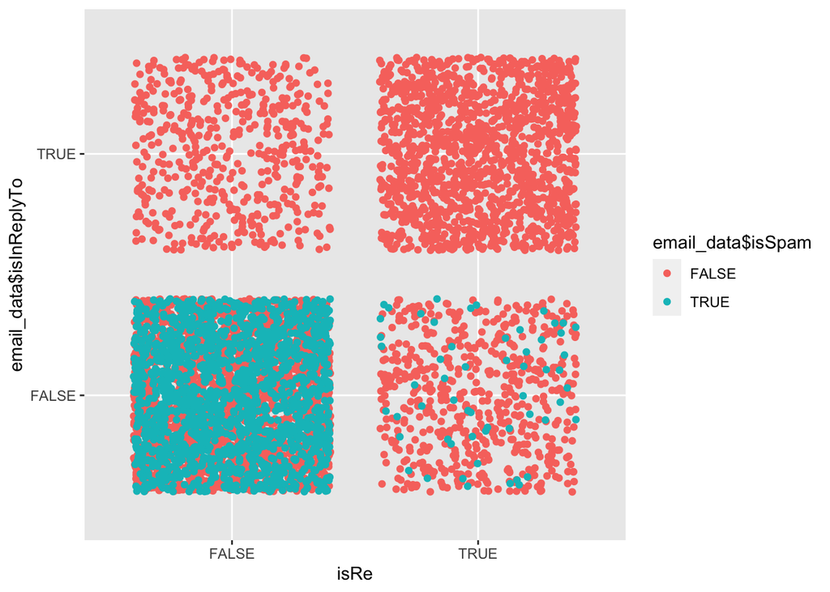

```r
ggplot(email_data, aes(y = email_data$isInReplyTo)) + geom_jitter(aes(isRe,colour = email_data$isSpam))
```

This plot shows the distribution of spam and non spam emails across the isRe and isInReplyTo variables. It is clear that there is a distinction of the characteristics of spam email in these two variables. Most spam emails are located in the square that indicates the string “Re:” is not the first to appear in the email’s subject line and that the header of the message has no field on its header for in-reply-to. The last one being the most determinant factor.

Simply for the sake of a clearer plot below are the plots with only one of each of those variables at a time:

### isSpam vs isRe

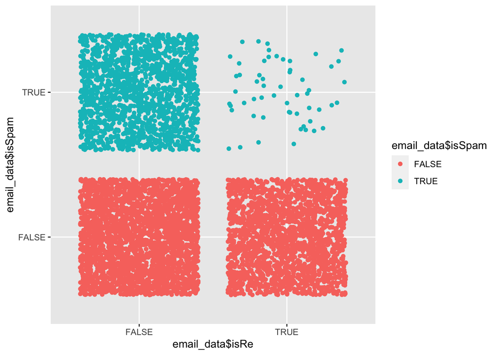

```r
ggplot(email_data, aes(x = email_data$isRe,y = email_data$isSpam, colour = email_data$isSpam)) + geom_jitter()
```

### isSpam vs isInReplyTo

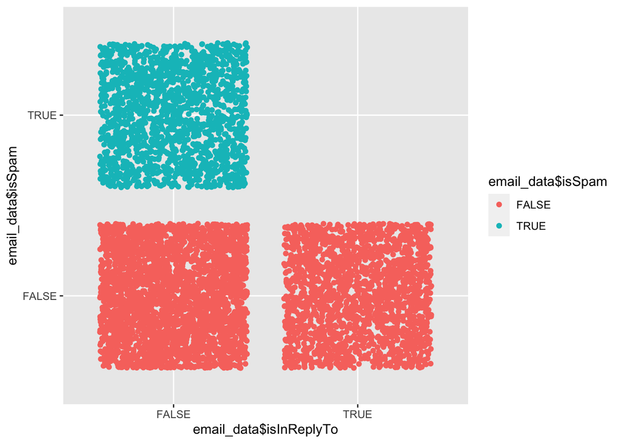

```r
ggplot(email_data, aes(x = email_data$isInReplyTo,y = email_data$isSpam, colour = email_data$isSpam)) + geom_jitter()
```

### Findings Summary

Based on the plots shown above it is notizable that some variables do show a contrast between spam and non-spam emails. For instance spam emails tend to have a higher percentage of capital letters in their subject lines as well as in their bodies and lengthier bodies. While I expected the number of attachments and special characters in the subject line to be a more determinant factor of spam, it showed no significant preference. In addition, two characteristics that dominated in non spam emails were isRe and isInReplyTo. It seems that almost if not all spam emails are missing both of these attributes which is why it would be a good idea to integrate those in a model to detect spam.